# Evaluación 3

### Exercise 4

1. Compute the centroid of your country. 2. Combine all the polygons to the north, and also all the polygons to the south; use unary union. 3. Detect the amount of duplicates after the combination. 4. Plot both maps so that duplicates appear.

```python
centroAustralia=australia.centroid
centroAustralia
```

```
0    POINT (32199.226 -2924192.688)
dtype: geometry
```

```python
type(centroAustralia), type(centroAustralia.x)
```

```
(geopandas.geoseries.GeoSeries, pandas.core.series.Series)
```

```python
type(centroAustralia.x[0]),type(centroAustralia.y[0])
```

```
(numpy.float64, numpy.float64)
```

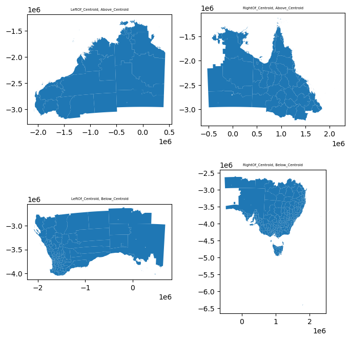

```python
fig, axs = plt.subplots(nrows=2,ncols=2,sharex=False, sharey=False,figsize=(8,8))

centroidX=centroAustralia.x[0]
centroidY=centroAustralia.y[0]

axs[0,0].set_title('LeftOf_Centroid, Above_Centroid',fontsize=5)
australia_municipalities.cx[:centroidX,centroidY:].plot(ax=axs[0,0])

axs[0,1].set_title('RightOf_Centroid, Above_Centroid',fontsize=5)
australia_municipalities.cx[centroidX:,centroidY:].plot(ax=axs[0,1])

axs[1,0].set_title('LeftOf_Centroid, Below_Centroid',fontsize=5)
australia_municipalities.cx[:centroidX,:centroidY].plot(ax=axs[1,0])

axs[1,1].set_title('RightOf_Centroid, Below_Centroid',fontsize=5)
australia_municipalities.cx[centroidX:,:centroidY].plot(ax=axs[1,1]) ;
```

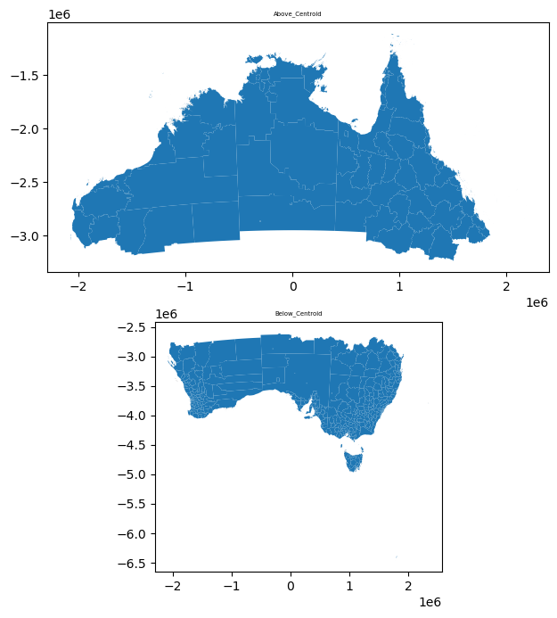

```python
# intepreting that "2. Combine all the polygons to the north, and also all the polygons to the south; use unary union."
# means that we just have to separte the maps in 2 parts, then we do the following:

fig, axs = plt.subplots(nrows=2, ncols=1, sharex=False, sharey=False, figsize=(8, 8))

centroidX = centroAustralia.x[0]
centroidY = centroAustralia.y[0]

axs[0].set_title('Above_Centroid', fontsize=5)
australia_municipalities.cx[:, centroidY:].plot(ax=axs[0])

axs[1].set_title('Below_Centroid', fontsize=5)
australia_municipalities.cx[:, :centroidY].plot(ax=axs[1])
```

```python
#instead of:
australia_municipalities.cx[:centroidX,centroidY:]
```

|  | GID_2 | GID_0 | COUNTRY | GID_1 | NAME_1 | NL_NAME_1 | NAME_2 | VARNAME_2 | NL_NAME_2 | TYPE_2 | ENGTYPE_2 | CC_2 | HASC_2 | geometry |
| --- | --- | --- | --- | --- | --- | --- | --- | --- | --- | --- | --- | --- | --- | --- |
| 0 | AUS.1.1_1 | AUS | Australia | AUS.1_1 | Ashmore and Cartier Islands | NA | Ashmore and Cartier Islands | NA | NA | Territory | Territory | NA | NA | MULTIPOLYGON (((-1155528.973 -1509855.849, -11... |
| 157 | AUS.6.1_1 | AUS | Australia | AUS.6_1 | Northern Territory | NA | Alice Springs | NA | NA | Town | Town | 70200 | AU.NT.AS | POLYGON ((-15871.214 -2691857.039, -13583.208 ... |
| 158 | AUS.6.2_1 | AUS | Australia | AUS.6_1 | Northern Territory | NA | Barkly | NA | NA | Shire | Shire | 70420 | NA | POLYGON ((-248605.898 -2110418.191, -248731.83... |
| 159 | AUS.6.3_1 | AUS | Australia | AUS.6_1 | Northern Territory | NA | Belyuen | NA | NA | Shire | Shire | 70540 | AU.NT.BE | POLYGON ((-370680.767 -1464180.284, -367348.48... |
| 160 | AUS.6.4_1 | AUS | Australia | AUS.6_1 | Northern Territory | NA | Central Desert | NA | NA | Shire | Shire | 70620 | NA | POLYGON ((-248605.898 -2110418.191, -241556.24... |
| 161 | AUS.6.5_1 | AUS | Australia | AUS.6_1 | Northern Territory | NA | Coomalie | NA | NA | Shire | Shire | 70700 | AU.NT.CO | POLYGON ((-308863.325 -1502372.904, -308867.26... |
| 162 | AUS.6.6_1 | AUS | Australia | AUS.6_1 | Northern Territory | NA | Darwin | NA | NA | City | City | 71000 | AU.NT.DR | MULTIPOLYGON (((-349111.551 -1456006.245, -349... |
| 164 | AUS.6.8_1 | AUS | Australia | AUS.6_1 | Northern Territory | NA | Katherine | NA | NA | Town | Town | 72200 | AU.NT.KA | MULTIPOLYGON (((-214324.468 -1651102.507, -214... |
| 165 | AUS.6.9_1 | AUS | Australia | AUS.6_1 | Northern Territory | NA | Litchfield | NA | NA | Municipality | Municipality | 72300 | AU.NT.LI | MULTIPOLYGON (((-337473.806 -1477390.125, -337... |
| 166 | AUS.6.10_1 | AUS | Australia | AUS.6_1 | Northern Territory | NA | MacDonnell | NA | NA | Shire | Shire | 72330 | NA | POLYGON ((-507305.181 -2635108.515, -463262.76... |
| 167 | AUS.6.11_1 | AUS | Australia | AUS.6_1 | Northern Territory | NA | Palmerston | NA | NA | City | City | 72800 | AU.NT.PA | MULTIPOLYGON (((-338638.222 -1465638.063, -338... |
| 168 | AUS.6.12_1 | AUS | Australia | AUS.6_1 | Northern Territory | NA | Roper Gulf | NA | NA | Shire | Shire | 73600 | NA | MULTIPOLYGON (((330639.367 -1839230.576, 33062... |
| 169 | AUS.6.13_1 | AUS | Australia | AUS.6_1 | Northern Territory | NA | Tiwi Islands | NA | NA | Shire | Shire | 74050 | NA | MULTIPOLYGON (((-407678.750 -1333014.833, -407... |
| 170 | AUS.6.14_1 | AUS | Australia | AUS.6_1 | Northern Territory | NA | Unincorporated Norther Territori | NA | NA | Unincorporated Area | Unincorporated Area | 79399 | NA | MULTIPOLYGON (((-299390.304 -2861703.438, -297... |
| 171 | AUS.6.15_1 | AUS | Australia | AUS.6_1 | Northern Territory | NA | Victoria-Daly | NA | NA | Shire | Shire | 74500 | NA | MULTIPOLYGON (((-171131.104 -1923651.717, -171... |
| 172 | AUS.6.16_1 | AUS | Australia | AUS.6_1 | Northern Territory | NA | Wagait | NA | NA | Shire | Shire | 74560 | NA | MULTIPOLYGON (((-359368.301 -1458020.123, -359... |
| 173 | AUS.6.17_1 | AUS | Australia | AUS.6_1 | Northern Territory | NA | West Arnhem | NA | NA | Shire | Shire | 74660 | NA | MULTIPOLYGON (((89516.760 -1421270.738, 85122.... |
| 430 | AUS.11.3_1 | AUS | Australia | AUS.11_1 | Western Australia | NA | Ashburton | NA | NA | Shire | Shire | 50250 | AU.WA.AS | MULTIPOLYGON (((-1630744.758 -2552130.355, -16... |
| 440 | AUS.11.13_1 | AUS | Australia | AUS.11_1 | Western Australia | NA | Broome | NA | NA | Shire | Shire | 50980 | AU.WA.BM | MULTIPOLYGON (((-1297286.183 -2225745.129, -12... |
| 449 | AUS.11.22_1 | AUS | Australia | AUS.11_1 | Western Australia | NA | Carnarvon | NA | NA | Shire | Shire | 51540 | AU.WA.CA | MULTIPOLYGON (((-1993319.082 -3037111.807, -19... |
| 467 | AUS.11.40_1 | AUS | Australia | AUS.11_1 | Western Australia | NA | Derby-West Kimberley | NA | NA | Shire | Shire | 52800 | AU.WA.DW | MULTIPOLYGON (((-1114636.641 -2192566.906, -11... |
| 473 | AUS.11.46_1 | AUS | Australia | AUS.11_1 | Western Australia | NA | East Pilbara | NA | NA | Shire | Shire | 53220 | AU.WA.EP | MULTIPOLYGON (((-511753.975 -2523015.944, -510... |
| 475 | AUS.11.48_1 | AUS | Australia | AUS.11_1 | Western Australia | NA | Exmouth | NA | NA | Shire | Shire | 53360 | AU.WA.EX | MULTIPOLYGON (((-2014168.105 -2721502.889, -20... |
| 482 | AUS.11.55_1 | AUS | Australia | AUS.11_1 | Western Australia | NA | Halls Creek | NA | NA | Shire | Shire | 53920 | AU.WA.HC | POLYGON ((-526328.149 -2158156.737, -524855.68... |
| 502 | AUS.11.75_1 | AUS | Australia | AUS.11_1 | Western Australia | NA | Meekatharra | NA | NA | Shire | Shire | 55250 | AU.WA.MT | POLYGON ((-1645672.509 -2816327.641, -1645947.... |
| 522 | AUS.11.95_1 | AUS | Australia | AUS.11_1 | Western Australia | NA | Ngaanyatjarraku | NA | NA | Shire | Shire | 56620 | AU.WA.NG | POLYGON ((-505471.438 -2680134.403, -505228.14... |
| 531 | AUS.11.104_1 | AUS | Australia | AUS.11_1 | Western Australia | NA | Port Hedland | NA | NA | Town | Town | 57280 | AU.WA.PO | MULTIPOLYGON (((-1582469.218 -2589622.291, -15... |
| 535 | AUS.11.108_1 | AUS | Australia | AUS.11_1 | Western Australia | NA | Roebourne | NA | NA | Shire | Shire | 57560 | AU.WA.RB | MULTIPOLYGON (((-1642895.991 -2560954.731, -16... |
| 537 | AUS.11.110_1 | AUS | Australia | AUS.11_1 | Western Australia | NA | Scott and Seringapatam Reefs | NA | NA | Islands | Islands | NA | NA | MULTIPOLYGON (((-1338334.321 -1704409.773, -13... |
| 548 | AUS.11.121_1 | AUS | Australia | AUS.11_1 | Western Australia | NA | Upper Gascoyne | NA | NA | Shire | Shire | 58470 | AU.WA.UG | POLYGON ((-1850096.215 -2832407.495, -1847978.... |
| 560 | AUS.11.133_1 | AUS | Australia | AUS.11_1 | Western Australia | NA | Wiluna | NA | NA | Shire | Shire | 59250 | AU.WA.WL | POLYGON ((-1342233.402 -2773772.805, -1342228.... |
| 564 | AUS.11.137_1 | AUS | Australia | AUS.11_1 | Western Australia | NA | Wyndham-East Kimberley | NA | NA | Shire | Shire | 59340 | AU.WA.WE | MULTIPOLYGON (((-540761.314 -1795627.499, -540... |

```python
# dissolving
australia_municipalities.cx[:centroidX,centroidY:].dissolve()
```

|  | geometry | GID_2 | GID_0 | COUNTRY | GID_1 | NAME_1 | NL_NAME_1 | NAME_2 | VARNAME_2 | NL_NAME_2 | TYPE_2 | ENGTYPE_2 | CC_2 | HASC_2 |
| --- | --- | --- | --- | --- | --- | --- | --- | --- | --- | --- | --- | --- | --- | --- |
| 0 | MULTIPOLYGON (((-1968223.173 -3073826.736, -19... | AUS.1.1_1 | AUS | Australia | AUS.1_1 | Ashmore and Cartier Islands | NA | Ashmore and Cartier Islands | NA | NA | Territory | Territory | NA | NA |

```python
type(australia_municipalities.cx[:centroidX,centroidY:].dissolve())
```

```
geopandas.geodataframe.GeoDataFrame
```

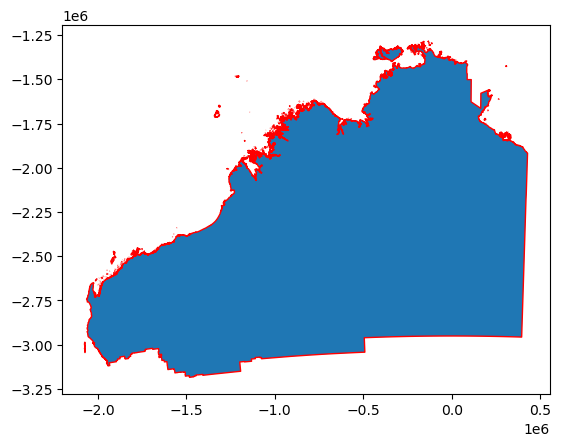

```python
# as a GeoDF we can plot:
australia_municipalities.cx[:centroidX,centroidY:].dissolve().plot(edgecolor='red')
```

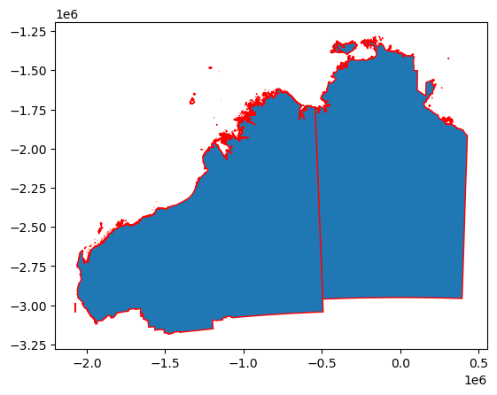

```python
# the municipalities by state
australia_municipalities.cx[:centroidX,centroidY:].dissolve(by='NAME_1').plot(edgecolor='red')
```

### Unary Union

This operation is used to combine all the geometries in one GeoDF:

```python
australia_municipalities.cx[:centroidX,centroidY:].unary_union
```

It looks like dissolve default behaviour, but:

```python
type(australia_municipalities.cx[:centroidX,centroidY:].unary_union)
```

```
shapely.geometry.multipolygon.MultiPolygon
```

The result is not a GeoDF. It is a *shapely* geometry. You could turn that into a GeoSeries:

```python
gpd.GeoDataFrame(index=[0],
                 crs=australia_municipalities.crs,
                 geometry=[australia_municipalities.cx[:centroidX,centroidY:].unary_union])
```

|  | geometry |
| --- | --- |
| 0 | MULTIPOLYGON (((-1968223.173 -3073826.736, -19... |

Notice that *unary union* erase all other columns; it only produces the geometry combined.

Let me use the dissolve this time:

```python
# you create
Australia_topleft=australia_municipalities.cx[:centroidX,centroidY:].dissolve()
# you get
Australia_topleft
```

|  | geometry | GID_2 | GID_0 | COUNTRY | GID_1 | NAME_1 | NL_NAME_1 | NAME_2 | VARNAME_2 | NL_NAME_2 | TYPE_2 | ENGTYPE_2 | CC_2 | HASC_2 |
| --- | --- | --- | --- | --- | --- | --- | --- | --- | --- | --- | --- | --- | --- | --- |
| 0 | MULTIPOLYGON (((-1968223.173 -3073826.736, -19... | AUS.1.1_1 | AUS | Australia | AUS.1_1 | Ashmore and Cartier Islands | NA | Ashmore and Cartier Islands | NA | NA | Territory | Territory | NA | NA |

Aside from the *COUNTRY* and *geometry* column, the rest is meaningless, then:

```python
Australia_topleft['zone']='NW' # add column
Australia_topleft=Australia_topleft.loc[:,['COUNTRY','zone','geometry']]   # keep some

# result
Australia_topleft
```

|  | COUNTRY | zone | geometry |
| --- | --- | --- | --- |
| 0 | Australia | NW | MULTIPOLYGON (((-1968223.173 -3073826.736, -19... |

```python
Australia_topRight=australia_municipalities.cx[centroidX:,centroidY:].dissolve()
Australia_bottomLeft=australia_municipalities.cx[:centroidX,:centroidY].dissolve()
Australia_bottomRight=australia_municipalities.cx[centroidX:,:centroidY].dissolve()

Australia_topRight['zone']='NE'
Australia_topRight=Australia_topRight.loc[:,['COUNTRY','zone','geometry']]

Australia_bottomLeft['zone']='NE'
Australia_bottomLeft=Australia_bottomLeft.loc[:,['COUNTRY','zone','geometry']]

Australia_bottomRight['zone']='NE'
Australia_bottomRight=Australia_bottomRight.loc[:,['COUNTRY','zone','geometry']]
```

Keep in mind that with **CX** we may not get a perfect partition:

```python
australia_municipalities
```

|  | GID_2 | GID_0 | COUNTRY | GID_1 | NAME_1 | NL_NAME_1 | NAME_2 | VARNAME_2 | NL_NAME_2 | TYPE_2 | ENGTYPE_2 | CC_2 | HASC_2 | geometry |
| --- | --- | --- | --- | --- | --- | --- | --- | --- | --- | --- | --- | --- | --- | --- |
| 0 | AUS.1.1_1 | AUS | Australia | AUS.1_1 | Ashmore and Cartier Islands | NA | Ashmore and Cartier Islands | NA | NA | Territory | Territory | NA | NA | MULTIPOLYGON (((-1155528.973 -1509855.849, -11... |
| 1 | AUS.2.1_1 | AUS | Australia | AUS.2_1 | Australian Capital Territory | NA | Unincorporated Australian Capita | NA | NA | Unincorporated Area | Unincorporated Area | 89399 | NA | POLYGON ((1377837.616 -4045794.766, 1377835.52... |
| 2 | AUS.3.1_1 | AUS | Australia | AUS.3_1 | Coral Sea Islands Territory | NA | Coral Sea Islands | NA | NA | Territory | Territory | NA | NA | MULTIPOLYGON (((2171096.644 -2836891.086, 2171... |
| 3 | AUS.4.1_1 | AUS | Australia | AUS.4_1 | Jervis Bay Territory | NA | Jervis Bay | NA | NA | Territory | Territory | 99399 | NA | MULTIPOLYGON (((1512782.961 -4060699.652, 1512... |
| 4 | AUS.5.1_1 | AUS | Australia | AUS.5_1 | New South Wales | NA | Albury | NA | NA | City | City | 10050 | AU.NS.AL | POLYGON ((1152924.677 -4116752.803, 1152946.80... |
| ... | ... | ... | ... | ... | ... | ... | ... | ... | ... | ... | ... | ... | ... | ... |
| 563 | AUS.11.136_1 | AUS | Australia | AUS.11_1 | Western Australia | NA | Wyalkatchem | NA | NA | Shire | Shire | 59330 | AU.WA.WY | POLYGON ((-1560889.257 -3650016.384, -1561690.... |
| 564 | AUS.11.137_1 | AUS | Australia | AUS.11_1 | Western Australia | NA | Wyndham-East Kimberley | NA | NA | Shire | Shire | 59340 | AU.WA.WE | MULTIPOLYGON (((-540761.314 -1795627.499, -540... |
| 565 | AUS.11.138_1 | AUS | Australia | AUS.11_1 | Western Australia | NA | Yalgoo | NA | NA | Shire | Shire | 59350 | AU.WA.YA | POLYGON ((-1632853.297 -3198738.049, -1632437.... |
| 566 | AUS.11.139_1 | AUS | Australia | AUS.11_1 | Western Australia | NA | Yilgarn | NA | NA | Shire | Shire | 59360 | AU.WA.YI | POLYGON ((-1329900.147 -3481057.815, -1328747.... |
| 567 | AUS.11.140_1 | AUS | Australia | AUS.11_1 | Western Australia | NA | York | NA | NA | Shire | Shire | 59370 | AU.WA.YO | POLYGON ((-1652261.056 -3737937.541, -1652731.... |

568 rows × 14 columns

```python
# let's calculate the difference:
# tuple with count of rows
rowsCX=(australia_municipalities.cx[:centroAustralia.x[0],centroAustralia.y[0]:].shape[0],\
        australia_municipalities.cx[centroAustralia.x[0]:,centroAustralia.y[0]:].shape[0],\
        australia_municipalities.cx[:centroAustralia.x[0],:centroAustralia.y[0]].shape[0],\
        australia_municipalities.cx[centroAustralia.x[0]:,:centroAustralia.y[0]].shape[0])

sum(rowsCX)
```

```
596
```

```python
# coincidences:
len(set(australia_municipalities.cx[:centroAustralia.x[0],centroAustralia.y[0]:].CC_2). \
intersection(set(australia_municipalities.cx[centroAustralia.x[0]:,centroAustralia.y[0]:].CC_2)). \
intersection(set(australia_municipalities.cx[:centroAustralia.x[0],:centroAustralia.y[0]].CC_2)). \
intersection(set(australia_municipalities.cx[centroAustralia.x[0]:,:centroAustralia.y[0]].CC_2)))
```

```
1
```

Adding up all the rows, we have more municipalities:

```python
australia_municipalities.shape[0]
```

```
568
```

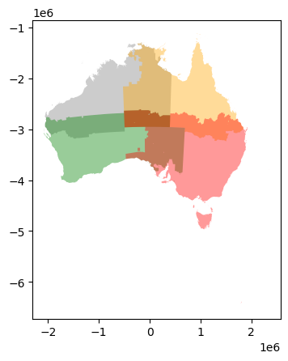

```python
base=Australia_topleft.plot(facecolor='grey', alpha=0.4)
Australia_topRight.plot(ax=base,facecolor='orange', alpha=0.4)
Australia_bottomLeft.plot(ax=base,facecolor='green', alpha=0.4)
Australia_bottomRight.plot(ax=base,facecolor='red', alpha=0.4)
```

### Exercise 5

1. Select some points from your maps. 2. Create the convex hull for those points. 3. Turn the hull into a GDF. 4. Plot the hull on top of the country.

Some time you may have the need to create a polygon that serves as an envelope to a set of points:

```python
Australia_AirTopLeft=airports[airports.kind=='medium_airport'].cx[:centroidX,centroidY:]
Australia_AirTopRight=airports[airports.kind=='medium_airport'].cx[centroidX:,centroidY:]
Australia_AirBottomLeft=airports[airports.kind=='medium_airport'].cx[:centroidX,:centroidY]
Australia_AirBottomRight=airports[airports.kind=='medium_airport'].cx[centroidX:,:centroidY]
```

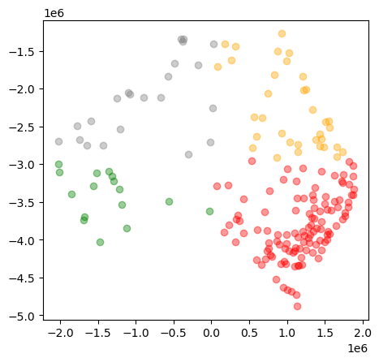

```python
# we are visualizing four subsets of data from 'au-airports', each with a
# different color, on the same plot. The resulting plot is stored in
# the variable 'base'
base=Australia_AirTopLeft.plot(facecolor='grey', alpha=0.4)
Australia_AirTopRight.plot(ax=base,facecolor='orange', alpha=0.4)
Australia_AirBottomLeft.plot(ax=base,facecolor='green', alpha=0.4)
Australia_AirBottomRight.plot(ax=base,facecolor='red', alpha=0.4)
```

```python
# now we have simple plots:
Australia_AirBottomLeft
```

|  | name | kind | latitude_deg | longitude_deg | elevation_ft | region_name | municipality | geometry |
| --- | --- | --- | --- | --- | --- | --- | --- | --- |
| 19 | Perth Jandakot Airport | medium_airport | -32.097500 | 115.880997 | 99.0 | Western Australia | Perth | POINT (-1689927.529 -3741605.826) |
| 31 | Kalgoorlie Boulder Airport | medium_airport | -30.791543 | 121.464586 | 1203.0 | Western Australia | Broadwood | POINT (-1185556.007 -3535306.304) |
| 41 | Geraldton Airport | medium_airport | -28.796101 | 114.707001 | 121.0 | Western Australia | Geraldton | POINT (-1853971.262 -3399988.280) |
| 54 | Albany Airport | medium_airport | -34.943298 | 117.808998 | 233.0 | Western Australia | Albany | POINT (-1470846.661 -4028237.256) |
| 90 | Meekatharra Airport | medium_airport | -26.611700 | 118.547997 | 1713.0 | Western Australia | NaN | POINT (-1516291.737 -3111609.802) |
| 93 | Ceduna Airport | medium_airport | -32.130600 | 133.710007 | 77.0 | South Australia | NaN | POINT (-27132.675 -3623240.035) |
| 94 | Carnarvon Airport | medium_airport | -24.880091 | 113.670752 | 13.0 | Western Australia | Carnarvon | POINT (-2021744.237 -2992610.184) |
| 120 | Esperance Airport | medium_airport | -33.684399 | 121.822998 | 470.0 | Western Australia | Esperance | POINT (-1120984.670 -3848657.149) |
| 126 | RAAF Base Pearce | medium_airport | -31.667801 | 116.014999 | 149.0 | Western Australia | Bullsbrook | POINT (-1684250.860 -3693065.706) |
| 127 | Forrest Airport | medium_airport | -30.836620 | 128.112811 | 511.0 | Western Australia | NaN | POINT (-557278.700 -3494131.108) |
| 214 | Shark Bay Airport | medium_airport | -25.897294 | 113.575802 | 111.0 | Western Australia | Denham | POINT (-2013085.922 -3104029.226) |
| 215 | Leonora Airport | medium_airport | -28.878099 | 121.315002 | 1217.0 | Western Australia | Leonora | POINT (-1220791.166 -3328042.874) |
| 323 | Leinster Airport | medium_airport | -27.843300 | 120.703003 | 1631.0 | Western Australia | NaN | POINT (-1291440.628 -3221460.127) |
| 324 | Mount Magnet Airport | medium_airport | -28.116100 | 117.842003 | 1354.0 | Western Australia | NaN | POINT (-1564083.291 -3283627.026) |
| 325 | Wiluna Airport | medium_airport | -26.629200 | 120.221001 | 1649.0 | Western Australia | NaN | POINT (-1352610.329 -3094415.689) |
| 342 | Mount Keith Airport | medium_airport | -27.287330 | 120.554937 | 1792.0 | Western Australia | NaN | POINT (-1312264.850 -3162482.712) |

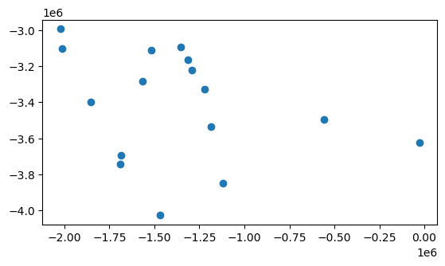

```python
Australia_AirBottomLeft.convex_hull.plot()
#I obtain point since the hull is made by row
```

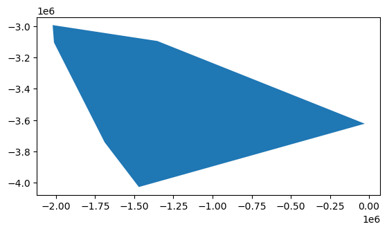

```python
# we need to disolve first:
Australia_AirBottomLeft.dissolve().convex_hull.plot()
```

```python
# convex hull is a polygon:
Australia_AirBottomLeft.dissolve().convex_hull
#el convex hull ha generado un solo polígono
```

```
0    POLYGON ((-1470846.661 -4028237.256, -1689927....
dtype: geometry
```

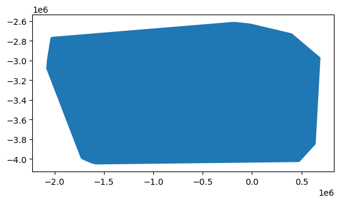

```python
# we can make hulls from any spatial object
Australia_bottomLeft.convex_hull.plot()
```

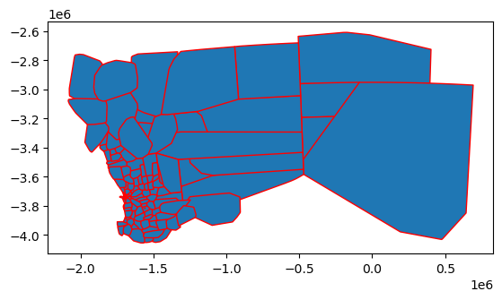

```python
australia_municipalities.cx[:centroidX,:centroidY].convex_hull.plot(edgecolor='red')
```

```python
# we can use *union* before creaing a convex hull:
# just the union:
large_airport=airports[airports.kind=='large_airport']
large_airport.unary_union
```

```python
# hull of the union
large_airport.unary_union.convex_hull
#primero los puntos deben estar agrupados y luego aplicar el convex hull para crear el polígono
```

```python
# let's turn the GS into a GDF:
LargeAirport_hull= gpd.GeoDataFrame(index=[0],
                                    crs=large_airport.crs,
                                    geometry=[large_airport.unary_union.convex_hull])
LargeAirport_hull['name']='large airports hull' # optional

# then

LargeAirport_hull
```

|  | geometry | name |
| --- | --- | --- |
| 0 | POLYGON ((960390.027 -4278051.009, -1684432.42... | large airports hull |

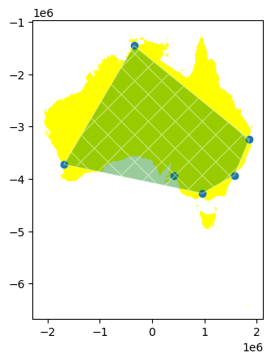

```python
# let's use the GDF in plotting:
base=australia.plot(facecolor='yellow')
large_airport.plot(ax=base)
LargeAirport_hull.plot(ax=base,facecolor='green',
                       edgecolor='white',alpha=0.4,
                       hatch='X')
```

### Exercise 6

1. Apply two of these operations to your maps. (de las 4: union, diferencia simetrica, interseccion, diferencia) 2. Apply two of these operations to the next maps:

```python
# let's create this GeoDFs:

# the north
MunisN_australia=australia_municipalities.cx[:,centroidY:]
# the south
MunisS_australia=australia_municipalities.cx[:,:centroidY]
# the west
MunisW_australia=australia_municipalities.cx[:centroidX,:]
# the east
MunisE_australia=australia_municipalities.cx[centroidX:,:]
```

### Intersection

We keep what is common in both GeoDFs:

```python
munisMidNS_australia=MunisN_australia.overlay(MunisN_australia, how="intersection",keep_geom_type=True)
munisMidNS_australia
```

|  | GID_2_1 | GID_0_1 | COUNTRY_1 | GID_1_1 | NAME_1_1 | NL_NAME_1_1 | NAME_2_1 | VARNAME_2_1 | NL_NAME_2_1 | TYPE_2_1 | ... | NAME_1_2 | NL_NAME_1_2 | NAME_2_2 | VARNAME_2_2 | NL_NAME_2_2 | TYPE_2_2 | ENGTYPE_2_2 | CC_2_2 | HASC_2_2 | geometry |
| --- | --- | --- | --- | --- | --- | --- | --- | --- | --- | --- | --- | --- | --- | --- | --- | --- | --- | --- | --- | --- | --- |
| 0 | AUS.1.1_1 | AUS | Australia | AUS.1_1 | Ashmore and Cartier Islands | NA | Ashmore and Cartier Islands | NA | NA | Territory | ... | Ashmore and Cartier Islands | NA | Ashmore and Cartier Islands | NA | NA | Territory | Territory | NA | NA | MULTIPOLYGON (((-1155534.741 -1509888.006, -11... |
| 1 | AUS.3.1_1 | AUS | Australia | AUS.3_1 | Coral Sea Islands Territory | NA | Coral Sea Islands | NA | NA | Territory | ... | Coral Sea Islands Territory | NA | Coral Sea Islands | NA | NA | Territory | Territory | NA | NA | MULTIPOLYGON (((2183608.116 -2718921.802, 2183... |
| 2 | AUS.6.1_1 | AUS | Australia | AUS.6_1 | Northern Territory | NA | Alice Springs | NA | NA | Town | ... | Northern Territory | NA | Alice Springs | NA | NA | Town | Town | 70200 | AU.NT.AS | POLYGON ((-13583.208 -2691855.219, -13523.120 ... |
| 3 | AUS.6.10_1 | AUS | Australia | AUS.6_1 | Northern Territory | NA | MacDonnell | NA | NA | Shire | ... | Northern Territory | NA | MacDonnell | NA | NA | Shire | Shire | 72330 | NA | POLYGON ((-463262.760 -2633431.609, -404235.87... |
| 4 | AUS.6.2_1 | AUS | Australia | AUS.6_1 | Northern Territory | NA | Barkly | NA | NA | Shire | ... | Northern Territory | NA | Barkly | NA | NA | Shire | Shire | 70420 | NA | POLYGON ((-248731.833 -2102207.237, -248764.89... |
| ... | ... | ... | ... | ... | ... | ... | ... | ... | ... | ... | ... | ... | ... | ... | ... | ... | ... | ... | ... | ... | ... |
| 81 | AUS.11.121_1 | AUS | Australia | AUS.11_1 | Western Australia | NA | Upper Gascoyne | NA | NA | Shire | ... | Western Australia | NA | Upper Gascoyne | NA | NA | Shire | Shire | 58470 | AU.WA.UG | POLYGON ((-1847978.211 -2832092.209, -1846347.... |
| 82 | AUS.11.13_1 | AUS | Australia | AUS.11_1 | Western Australia | NA | Broome | NA | NA | Shire | ... | Western Australia | NA | Broome | NA | NA | Shire | Shire | 50980 | AU.WA.BM | MULTIPOLYGON (((-1149058.486 -2036652.487, -11... |
| 83 | AUS.11.40_1 | AUS | Australia | AUS.11_1 | Western Australia | NA | Derby-West Kimberley | NA | NA | Shire | ... | Western Australia | NA | Derby-West Kimberley | NA | NA | Shire | Shire | 52800 | AU.WA.DW | MULTIPOLYGON (((-1104098.231 -2191682.947, -11... |
| 84 | AUS.11.133_1 | AUS | Australia | AUS.11_1 | Western Australia | NA | Wiluna | NA | NA | Shire | ... | Western Australia | NA | Wiluna | NA | NA | Shire | Shire | 59250 | AU.WA.WL | POLYGON ((-1342228.474 -2773772.285, -1341164.... |
| 85 | AUS.11.110_1 | AUS | Australia | AUS.11_1 | Western Australia | NA | Scott and Seringapatam Reefs | NA | NA | Islands | ... | Western Australia | NA | Scott and Seringapatam Reefs | NA | NA | Islands | Islands | NA | NA | MULTIPOLYGON (((-1313805.273 -1648788.406, -13... |

86 rows × 27 columns

```python
# this is similar to a *spatial join*:
MunisN_australia.sjoin(MunisS_australia, how="inner", predicate='contains')
```

|  | GID_2_left | GID_0_left | COUNTRY_left | GID_1_left | NAME_1_left | NL_NAME_1_left | NAME_2_left | VARNAME_2_left | NL_NAME_2_left | TYPE_2_left | ... | GID_1_right | NAME_1_right | NL_NAME_1_right | NAME_2_right | VARNAME_2_right | NL_NAME_2_right | TYPE_2_right | ENGTYPE_2_right | CC_2_right | HASC_2_right |
| --- | --- | --- | --- | --- | --- | --- | --- | --- | --- | --- | --- | --- | --- | --- | --- | --- | --- | --- | --- | --- | --- |
| 166 | AUS.6.10_1 | AUS | Australia | AUS.6_1 | Northern Territory | NA | MacDonnell | NA | NA | Shire | ... | AUS.6_1 | Northern Territory | NA | MacDonnell | NA | NA | Shire | Shire | 72330 | NA |
| 176 | AUS.7.3_1 | AUS | Australia | AUS.7_1 | Queensland | NA | Banana | NA | NA | Shire | ... | AUS.7_1 | Queensland | NA | Banana | NA | NA | Shire | Shire | 30370 | AU.QL.BN |
| 178 | AUS.7.5_1 | AUS | Australia | AUS.7_1 | Queensland | NA | Barcoo | NA | NA | Shire | ... | AUS.7_1 | Queensland | NA | Barcoo | NA | NA | Shire | Shire | 30450 | AU.QL.BQ |
| 179 | AUS.7.6_1 | AUS | Australia | AUS.7_1 | Queensland | NA | Blackall Tambo | NA | NA | Region | ... | AUS.7_1 | Queensland | NA | Blackall Tambo | NA | NA | Region | Region | 30760 | NA |
| 183 | AUS.7.10_1 | AUS | Australia | AUS.7_1 | Queensland | NA | Bundaberg | NA | NA | Region | ... | AUS.7_1 | Queensland | NA | Bundaberg | NA | NA | Region | Region | 31820 | AU.QL.BB |
| 189 | AUS.7.16_1 | AUS | Australia | AUS.7_1 | Queensland | NA | Central Highlands | NA | NA | Region | ... | AUS.7_1 | Queensland | NA | Central Highlands | NA | NA | Region | Region | 32270 | AU.TS.CH |
| 195 | AUS.7.22_1 | AUS | Australia | AUS.7_1 | Queensland | NA | Diamantina | NA | NA | Shire | ... | AUS.7_1 | Queensland | NA | Diamantina | NA | NA | Shire | Shire | 32750 | AU.QL.DI |
| 200 | AUS.7.27_1 | AUS | Australia | AUS.7_1 | Queensland | NA | Gladstone | NA | NA | Region | ... | AUS.7_1 | Queensland | NA | Gladstone | NA | NA | Region | Region | 33360 | AU.QL.GL |
| 215 | AUS.7.42_1 | AUS | Australia | AUS.7_1 | Queensland | NA | Maranoa | NA | NA | Region | ... | AUS.7_1 | Queensland | NA | Maranoa | NA | NA | Region | Region | 34860 | NA |
| 220 | AUS.7.47_1 | AUS | Australia | AUS.7_1 | Queensland | NA | Murweh | NA | NA | Shire | ... | AUS.7_1 | Queensland | NA | Murweh | NA | NA | Shire | Shire | 35600 | AU.QL.MW |
| 222 | AUS.7.49_1 | AUS | Australia | AUS.7_1 | Queensland | NA | North Burnett | NA | NA | Region | ... | AUS.7_1 | Queensland | NA | North Burnett | NA | NA | Region | Region | 35760 | NA |
| 227 | AUS.7.54_1 | AUS | Australia | AUS.7_1 | Queensland | NA | Quilpie | NA | NA | Shire | ... | AUS.7_1 | Queensland | NA | Quilpie | NA | NA | Shire | Shire | 36150 | AU.QL.QP |
| 449 | AUS.11.22_1 | AUS | Australia | AUS.11_1 | Western Australia | NA | Carnarvon | NA | NA | Shire | ... | AUS.11_1 | Western Australia | NA | Carnarvon | NA | NA | Shire | Shire | 51540 | AU.WA.CA |
| 502 | AUS.11.75_1 | AUS | Australia | AUS.11_1 | Western Australia | NA | Meekatharra | NA | NA | Shire | ... | AUS.11_1 | Western Australia | NA | Meekatharra | NA | NA | Shire | Shire | 55250 | AU.WA.MT |
| 522 | AUS.11.95_1 | AUS | Australia | AUS.11_1 | Western Australia | NA | Ngaanyatjarraku | NA | NA | Shire | ... | AUS.11_1 | Western Australia | NA | Ngaanyatjarraku | NA | NA | Shire | Shire | 56620 | AU.WA.NG |
| 548 | AUS.11.121_1 | AUS | Australia | AUS.11_1 | Western Australia | NA | Upper Gascoyne | NA | NA | Shire | ... | AUS.11_1 | Western Australia | NA | Upper Gascoyne | NA | NA | Shire | Shire | 58470 | AU.WA.UG |
| 560 | AUS.11.133_1 | AUS | Australia | AUS.11_1 | Western Australia | NA | Wiluna | NA | NA | Shire | ... | AUS.11_1 | Western Australia | NA | Wiluna | NA | NA | Shire | Shire | 59250 | AU.WA.WL |

17 rows × 28 columns

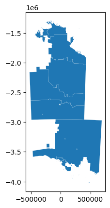

```python
# keeping the overlay
munisMidWE_australia=MunisW_australia.overlay(MunisE_australia, how="intersection",keep_geom_type=True)
munisMidWE_australia.plot(edgecolor='white',linewidth=0.1)
```

### Union

Let's unite the previous two GeoDF

```python
munisMidNS_australia.info()
```

```
<class 'geopandas.geodataframe.GeoDataFrame'>
RangeIndex: 86 entries, 0 to 85
Data columns (total 27 columns):
 #   Column       Non-Null Count  Dtype
---  ------       --------------  -----
 0   GID_2_1      86 non-null     object
 1   GID_0_1      86 non-null     object
 2   COUNTRY_1    86 non-null     object
 3   GID_1_1      86 non-null     object
 4   NAME_1_1     86 non-null     object
 5   NL_NAME_1_1  86 non-null     object
 6   NAME_2_1     86 non-null     object
 7   VARNAME_2_1  86 non-null     object
 8   NL_NAME_2_1  86 non-null     object
 9   TYPE_2_1     86 non-null     object
```

[output cut: 19 more lines]

```python
munisMidWE_australia.info()
```

```
<class 'geopandas.geodataframe.GeoDataFrame'>
RangeIndex: 10 entries, 0 to 9
Data columns (total 27 columns):
 #   Column       Non-Null Count  Dtype
---  ------       --------------  -----
 0   GID_2_1      10 non-null     object
 1   GID_0_1      10 non-null     object
 2   COUNTRY_1    10 non-null     object
 3   GID_1_1      10 non-null     object
 4   NAME_1_1     10 non-null     object
 5   NL_NAME_1_1  10 non-null     object
 6   NAME_2_1     10 non-null     object
 7   VARNAME_2_1  10 non-null     object
 8   NL_NAME_2_1  10 non-null     object
 9   TYPE_2_1     10 non-null     object
```

[output cut: 19 more lines]

```python
# NOTE: The overlay combines the geometries, but not the attributes
# Let's subset and show you:

keep=['COUNTRY_1','NAME_1_1','NAME_2_1','geometry']
munisMidNS_australia=munisMidNS_australia.loc[:,keep]
munisMidWE_australia=munisMidWE_australia.loc[:,keep]
```

```python
# now
munisMidNS_australia.overlay(munisMidWE_australia,how="union",keep_geom_type=True)
```

|  | COUNTRY_1_1 | NAME_1_1_1 | NAME_2_1_1 | COUNTRY_1_2 | NAME_1_1_2 | NAME_2_1_2 | geometry |
| --- | --- | --- | --- | --- | --- | --- | --- |
| 0 | Australia | Northern Territory | MacDonnell | Australia | Northern Territory | MacDonnell | POLYGON ((-404235.875 -2631422.335, -374178.76... |
| 1 | Australia | Northern Territory | Central Desert | Australia | Northern Territory | Central Desert | POLYGON ((-208921.251 -2109700.798, -208618.38... |
| 2 | Australia | Northern Territory | Unincorporated Norther Territori | Australia | Northern Territory | Unincorporated Norther Territori | MULTIPOLYGON (((307697.016 -1426964.344, 30757... |
| 3 | Australia | Northern Territory | Barkly | Australia | Northern Territory | Barkly | POLYGON ((-248764.894 -2100051.351, -248839.02... |
| 4 | Australia | Northern Territory | Roper Gulf | Australia | Northern Territory | Roper Gulf | MULTIPOLYGON (((381593.109 -2034620.946, 38165... |
| ... | ... | ... | ... | ... | ... | ... | ... |
| 85 | Australia | Western Australia | Scott and Seringapatam Reefs | NaN | NaN | NaN | MULTIPOLYGON (((-1313805.273 -1648788.406, -13... |
| 86 | NaN | NaN | NaN | Australia | South Australia | Unincorporated South Australia | MULTIPOLYGON (((668988.031 -3383679.725, 66881... |
| 87 | NaN | NaN | NaN | Australia | South Australia | Ceduna | POLYGON ((47946.046 -3635035.074, 47931.918 -3... |
| 88 | NaN | NaN | NaN | Australia | South Australia | Streaky Bay | MULTIPOLYGON (((11231.158 -3650360.754, 14220.... |
| 89 | NaN | NaN | NaN | Australia | South Australia | Elliston | MULTIPOLYGON (((176141.048 -3775156.233, 17609... |

90 rows × 7 columns

```python
# appending
pd.concat([munisMidNS_australia,munisMidWE_australia],ignore_index=True)
```

|  | COUNTRY_1 | NAME_1_1 | NAME_2_1 | geometry |
| --- | --- | --- | --- | --- |
| 0 | Australia | Ashmore and Cartier Islands | Ashmore and Cartier Islands | MULTIPOLYGON (((-1155534.741 -1509888.006, -11... |
| 1 | Australia | Coral Sea Islands Territory | Coral Sea Islands | MULTIPOLYGON (((2183608.116 -2718921.802, 2183... |
| 2 | Australia | Northern Territory | Alice Springs | POLYGON ((-13583.208 -2691855.219, -13523.120 ... |
| 3 | Australia | Northern Territory | MacDonnell | POLYGON ((-463262.760 -2633431.609, -404235.87... |
| 4 | Australia | Northern Territory | Barkly | POLYGON ((-248731.833 -2102207.237, -248764.89... |
| ... | ... | ... | ... | ... |
| 91 | Australia | South Australia | Unincorporated South Australia | MULTIPOLYGON (((670611.496 -3354194.089, 66978... |
| 92 | Australia | Northern Territory | West Arnhem | MULTIPOLYGON (((85122.063 -1428393.689, 84914.... |
| 93 | Australia | South Australia | Ceduna | POLYGON ((47946.046 -3635035.074, 47931.918 -3... |
| 94 | Australia | South Australia | Streaky Bay | MULTIPOLYGON (((11231.158 -3650360.754, 14220.... |
| 95 | Australia | South Australia | Elliston | MULTIPOLYGON (((176141.048 -3775156.233, 17609... |

96 rows × 4 columns

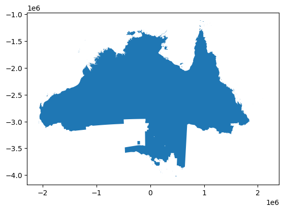

```python
munisMidNS_australia.dissolve().overlay(munisMidWE_australia.dissolve(), how="union",keep_geom_type=True).dissolve().plot()
#estas son las intersecciones
```

```python
muniMidAustralia=munisMidNS_australia.dissolve().overlay(munisMidWE_australia.dissolve(), how="union",keep_geom_type=True).dissolve()
muniMidAustralia
```

|  | geometry | COUNTRY_1_1 | NAME_1_1_1 | NAME_2_1_1 | COUNTRY_1_2 | NAME_1_1_2 | NAME_2_1_2 |
| --- | --- | --- | --- | --- | --- | --- | --- |
| 0 | MULTIPOLYGON (((-1968535.385 -3073824.569, -19... | Australia | Ashmore and Cartier Islands | Ashmore and Cartier Islands | Australia | Northern Territory | MacDonnell |

```python
# some cleaning

muniMidAustralia['zone']='middles'
muniMidAustralia=muniMidAustralia.loc[:,['COUNTRY_1_1','zone','geometry']]
muniMidAustralia
```

|  | COUNTRY_1_1 | zone | geometry |
| --- | --- | --- | --- |
| 0 | Australia | middles | MULTIPOLYGON (((-1968535.385 -3073824.569, -19... |

```python
# hulls for the mid size airports:
Australia_AirTopLeft_hull=Australia_AirTopLeft.dissolve().convex_hull
Australia_AirTopRight_hull=Australia_AirTopRight.dissolve().convex_hull
Australia_AirBottomLeft_hull=Australia_AirBottomLeft.dissolve().convex_hull
Australia_AirBottomRight_hull=Australia_AirBottomRight.dissolve().convex_hull
```

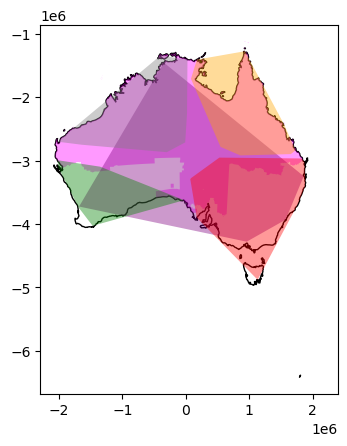

```python
base = australia.plot(color='white', edgecolor='black') #unprojected
muniMidAustralia.plot(ax=base,facecolor='magenta',alpha=0.4) #unprojected
LargeAirport_hull.plot(ax=base,facecolor='purple',alpha=0.4)
Australia_AirTopLeft_hull.plot(ax=base,facecolor='grey', alpha=0.4)
Australia_AirTopRight_hull.plot(ax=base,facecolor='orange', alpha=0.4)
Australia_AirBottomLeft_hull.plot(ax=base,facecolor='green', alpha=0.4)
Australia_AirBottomRight_hull.plot(ax=base,facecolor='red', alpha=0.4)
```

#### Validity of Geometry

Geometries are created in a way that some issues may appear, especially in (multi) polygons. Let's check if our recent maps on states and municipalities are valid:

```python
# non valid
australia_municipalities[~australia_municipalities.is_valid]
```

|  | GID_2 | GID_0 | COUNTRY | GID_1 | NAME_1 | NL_NAME_1 | NAME_2 | VARNAME_2 | NL_NAME_2 | TYPE_2 | ENGTYPE_2 | CC_2 | HASC_2 | geometry |
| --- | --- | --- | --- | --- | --- | --- | --- | --- | --- | --- | --- | --- | --- | --- |

```python
# non valid
australia_municipalities[~austalia_municipalities.is_valid]
```

[output not shown]